# Multiple_Linear_Regression

## 02 Forward Selection

```
1. Choose the significance level (SL = 0.05).
2. Fit all possible simple regression models and select the one with the lowest P-value.
3. Keep this variable and fit all possible models with one extra predictor added to the one you already have.
4. Find the predictor with the lowest P-value. If P < Sl, go back to step 3. Otherwise, you’re done!
```

### I Forward selection using SignifReg package

```r
library(SignifReg)
nullmodel = lm(Rings~1, data=abalone)
fullmodel = lm(Rings~Type.I + Type.M+ LongestShell+ Diameter+ WholeWeight+ ShuckedWeight+ VisceraWeight+ ShellWeight, data=abalone)
scope = list(lower=formula(nullmodel),upper=formula(fullmodel))

sub.model2=add1SignifReg(nullmodel,scope, alpha = 0.05, criterion = "p-value",override="TRUE")
summary(sub.model2)
```

```
##
## Call:
## lm(formula = Rings ~ LongestShell, data = abalone)
##
## Residuals:
##     Min      1Q  Median      3Q     Max
## -5.9665 -1.6961 -0.7423  0.8733 16.6776
##
## Coefficients:
##              Estimate Std. Error t value Pr(>|t|)
## (Intercept)    2.1019     0.1855   11.33   <2e-16 ***
## LongestShell  14.9464     0.3452   43.30   <2e-16 ***
## ---
## Signif. codes:  0 '***' 0.001 '**' 0.01 '*' 0.05 '.' 0.1 ' ' 1
##
## Residual standard error: 2.679 on 4175 degrees of freedom
## Multiple R-squared:  0.3099, Adjusted R-squared:  0.3098
## F-statistic:  1875 on 1 and 4175 DF,  p-value: < 2.2e-16
```

```
1.Select a significance level to enter and a significance level to stay.

2.Perform the next step of forward selection where you add the new variable.

3.Now perform all of the steps of backward elimination.

4.Now head back to step two, then move forward to step 3, and so on until no new variables can enter and no new variables can exit.
```

```r
model2 <-  lm(Rings~Type.I + Type.M+ LongestShell+ Diameter+ WholeWeight+ ShuckedWeight+ VisceraWeight+ ShellWeight,data=abalone)
step.model2 <- step(model2, direction = "forward", trace=FALSE)
summary(step.model2)
```

```
##
## Call:
## lm(formula = Rings ~ Type.I + Type.M + LongestShell + Diameter +
##     WholeWeight + ShuckedWeight + VisceraWeight + ShellWeight,
##     data = abalone)
##
## Residuals:
##     Min      1Q  Median      3Q     Max
## -8.1813 -1.3130 -0.3437  0.8690 13.7654
##
## Coefficients:
##                Estimate Std. Error t value Pr(>|t|)
## (Intercept)     4.24786    0.28883  14.707  < 2e-16 ***
## Type.I         -0.87919    0.10269  -8.562  < 2e-16 ***
## Type.M          0.04437    0.08380   0.529    0.597
## LongestShell   -0.05352    1.81860  -0.029    0.977
## Diameter       12.73487    2.22738   5.717 1.16e-08 ***
## WholeWeight     9.06362    0.72947  12.425  < 2e-16 ***
## ShuckedWeight -19.95631    0.82169 -24.287  < 2e-16 ***
## VisceraWeight -10.18938    1.29997  -7.838 5.76e-15 ***
## ShellWeight     9.57238    1.12490   8.510  < 2e-16 ***
## ---
## Signif. codes:  0 '***' 0.001 '**' 0.01 '*' 0.05 '.' 0.1 ' ' 1
##
## Residual standard error: 2.207 on 4168 degrees of freedom
## Multiple R-squared:  0.5324, Adjusted R-squared:  0.5315
## F-statistic: 593.3 on 8 and 4168 DF,  p-value: < 2.2e-16
```

### Backward Elimination (Stepwise Backward Selection)

Starts with: The full model (all predictors included). Process:

Removes the least significant predictor (highest p-value) one at a time. Reassesses the model after each removal. Stops when all remaining predictors are statistically significant (p-value < α, usually 0.05).

### Forward Selection (Stepwise Forward Selection)

Starts with: The null model (only intercept, no predictors). Process:

Adds the most significant predictor (lowest p-value or highest contribution to model improvement). Continues adding variables one at a time based on statistical significance. Stops when adding another variable does not significantly improve the model (p-value > α).

# Model Diagnosis

Regression diagnostics are used to evaluate the model assumptions and investigate whether or not there are observations with a large, undue influence on the analysis.

## Model Assumptions

Before using a regression model for interpreting the data, we must check that the model assumptions are met.

Basic assumptions of regression models:

```
 1. Linearity of the data: The relationship between the predictor (x) and the outcome (y) is assumed to be linear.

2. Normality of residuals: The residual errors are assumed to be normally distributed.

3. Homogeneity of residuals variance: The residuals are assumed to have a constant variance (homoscedasticity)

4. Independence of residuals error terms.
```

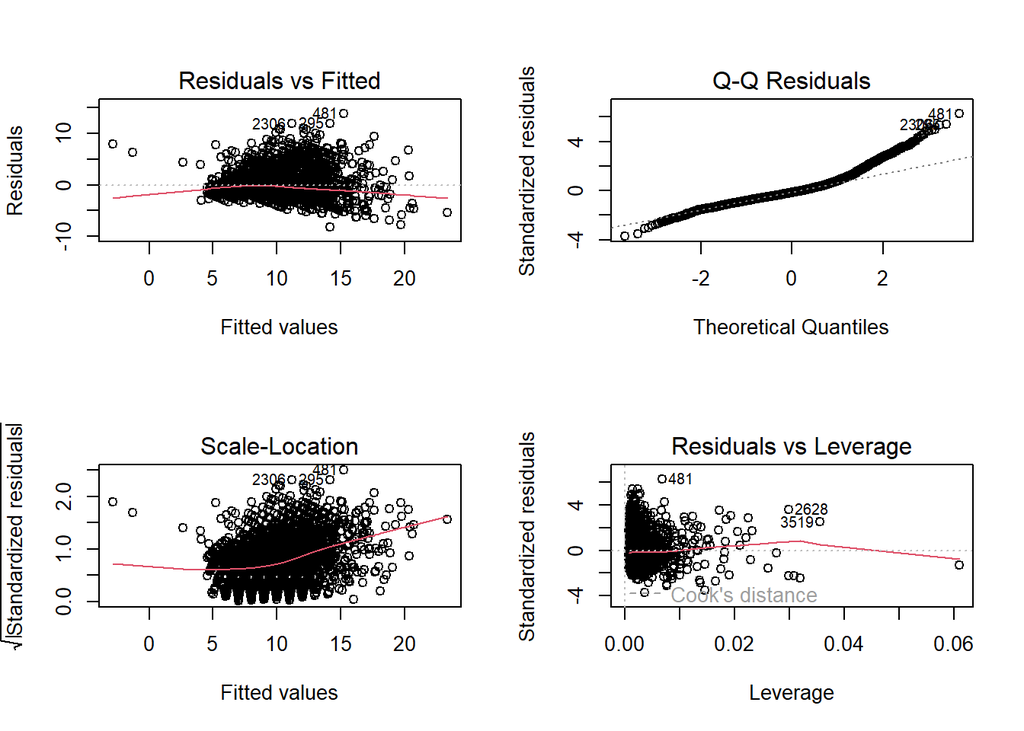

```r
par(mfrow =c(2,2))

# par() function in R is used to set or query graphical parameters.
#mfrow stands for "multi-frame row-wise layout" and determines how multiple plots are arranged in #a single plotting window.
#c(2,2) means divide the plotting area into a 2×2 grid, meaning 4 plots will be displayed in a 2-row, 2-column format.

plot(step.model2)
```

## Using ggfortify Package

```r
par(mfrow = c(2, 2))
library(ggfortify)
```

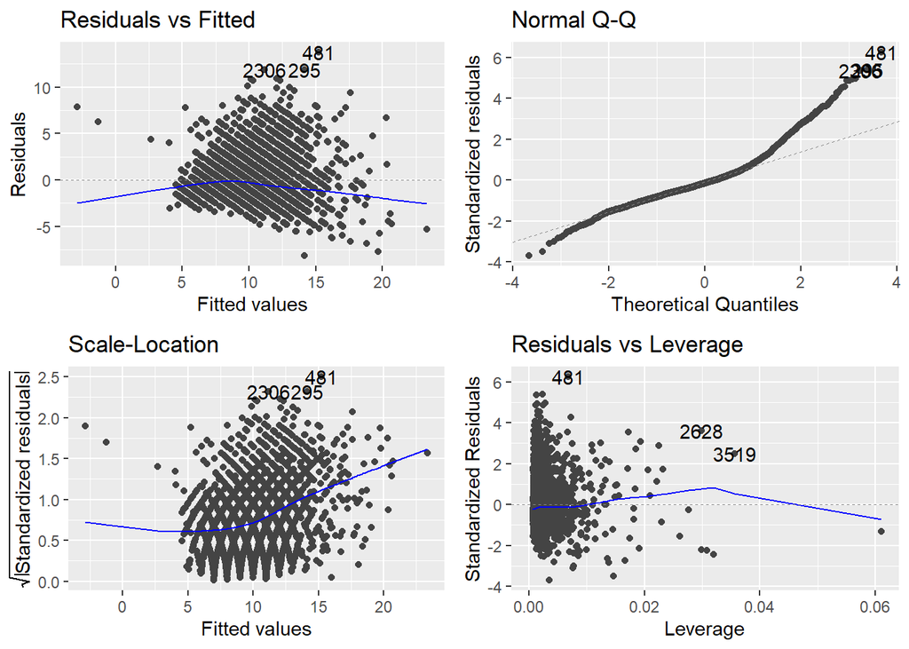

```r
autoplot(step.model2)
```

The diagnostic plots show residuals in four different ways:

```
1. Residuals vs Fitted: to check the linear relationship assumptions.

2. Normal Q-Q: to examine whether the residuals are normally distributed.

3. Scale-Location (or Spread-Location): to check the homogeneity of variance of the residuals (homoscedasticity).

4. Residuals vs Leverage: to identify extreme values that might influence the regression analysis.
```

# Identifying Influential OutLiers

An outlier is a point which is often distant from the others.

It is a point with a large value of its residual.

Different residual measures can be used to identify outliers.

```
 1. Standardised residuals

 2. Studentized residuals

 3. Cook’s distance
```

### 1. Standardised residuals

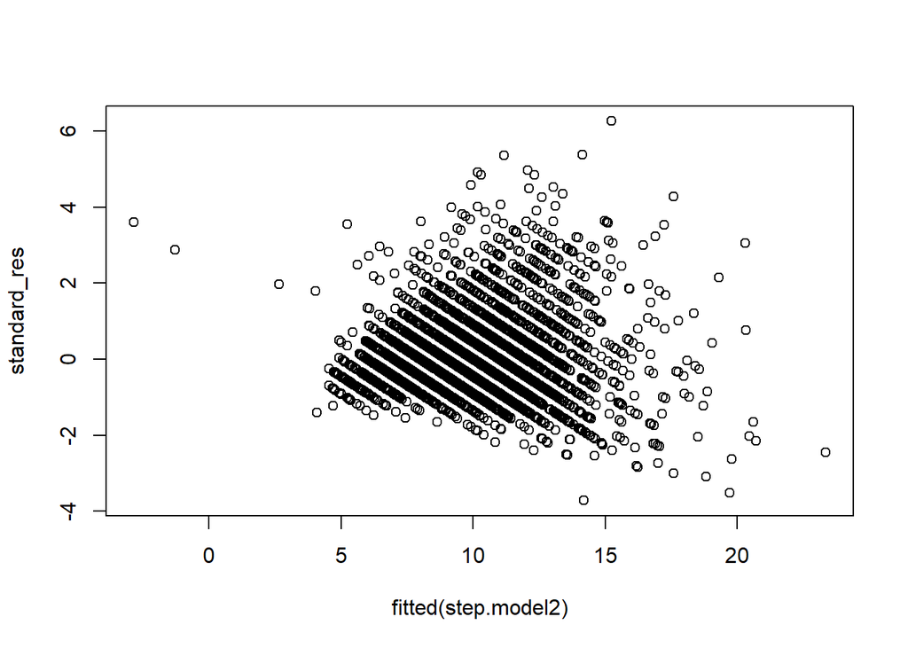

```r
standard_res=rstandard(step.model2)
plot(fitted(step.model2), standard_res)
```

#### Standardized residuals are “mostly” between 2 and 2, but they are dependent.

### 1. Studentized residuals

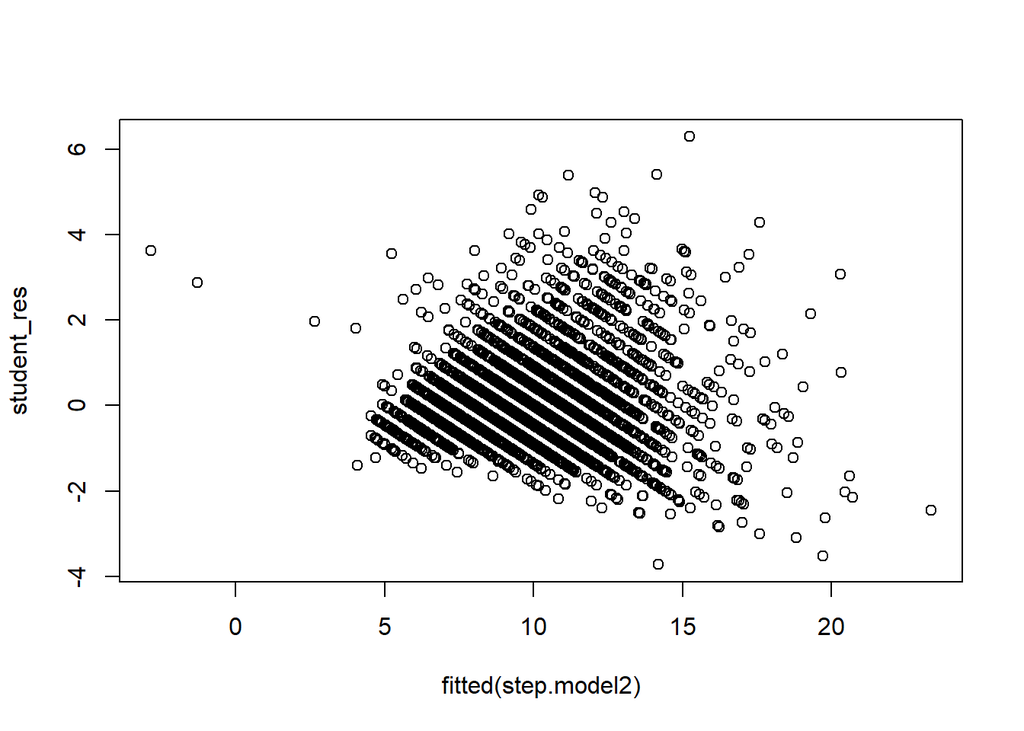

```r
student_res=rstudent(step.model2)
plot(fitted(step.model2), student_res)
```

For an outlier the absolute values of its Studentized residual is greater than the 0.975th quantile of the Student distribution with n−p−2 degrees of freedom

## Cook’s Distance

```
It is calculated by removing the ith data point from the model and refitting the regression model.

It summarizes how much all the values in the regression model change when the ith observation is removed.

The formula for Cook’s distance is:

    Di = (Sum(Yj-Yj^-i)^2)/(p+1)s^2

An R function to calculate Cook’s distance is cooks.distance().
```

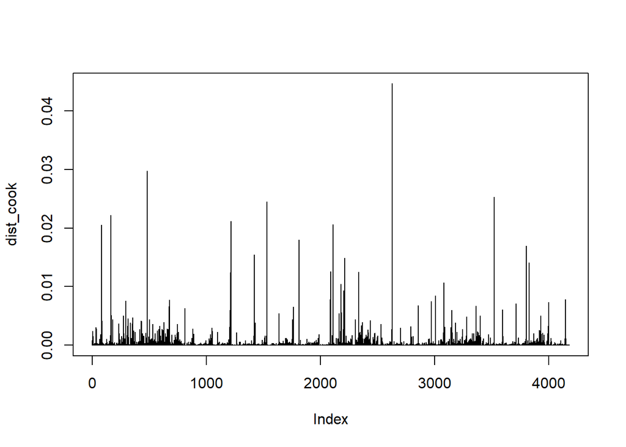

```r
dist_cook=cooks.distance(step.model2)
plot(dist_cook, type="h")
```

## Checking for multicollinearity

```
It is a statistical terminology where more than one independent variable is correlated with each other.

Results in reducing the reliability of statistical inferences.

Hence, these variables must be removed when building a multiple regression model.

Variance inflation factor (VIF) is used for detecting the multicollinearity in a model.
```

## Variance inflation factor

```r
library(car)
```

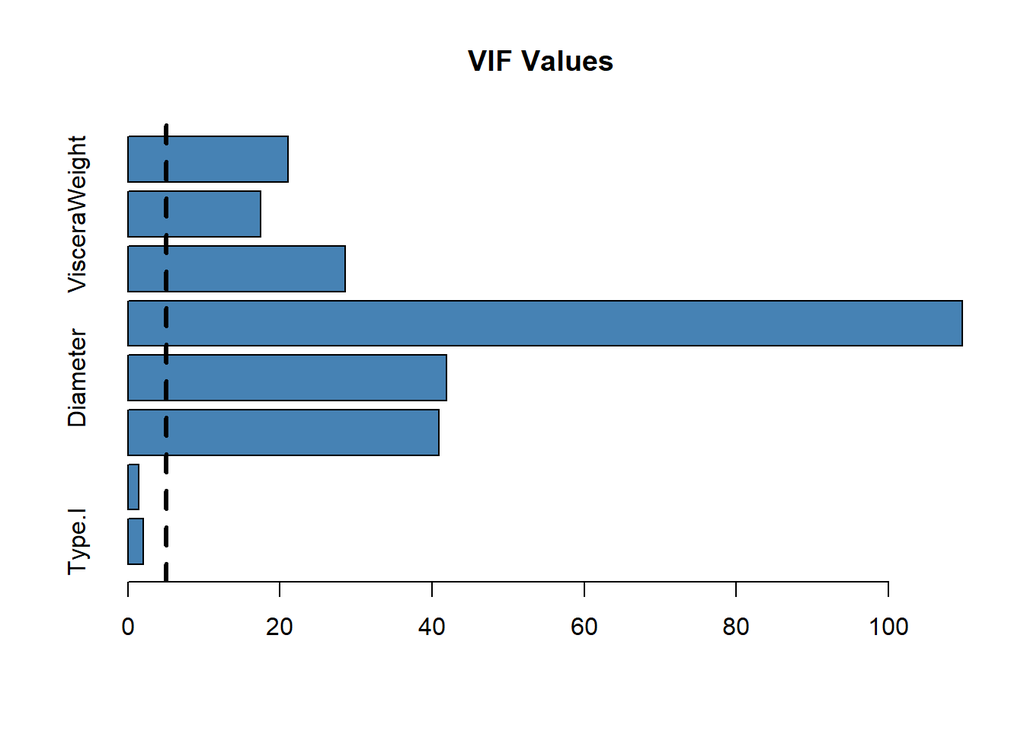

```r
vif_values <- vif(step.model2)
barplot(vif_values, main = "VIF Values", horiz = TRUE, col = "steelblue")
abline(v = 5, lwd = 3, lty = 2)
```